# Biostat 203B Homework 2 Solution

Due Friday Feb 12 @ 11:59PM

Kelsey Ishimoto

```r
knitr::opts_chunk$set(echo = TRUE, cache = TRUE)
```

```r
library(tidyverse)
library(data.table)
library(lubridate)
library(stringr)
```

```r
os <- sessionInfo()$running
if (str_detect(os, "Linux")) {
  mimic_path <- "/usr/203b-data/mimic-iv"
  mimic_path2 <- "/usr/203b-data/mimic-iv-derived-data"
} else if (str_detect(os, "macOS")) {
  mimic_path <- "/Users/huazhou/Documents/Box Sync/MIMIC/mimic-iv-0.4"
} else if (str_detect(os, "Windows")) {
  mimic_path <- "/Users/kmish/Documents/Biostat203b/MIMIC-IV"
  mimic_path2 <- mimic_path
  #setwd("~/Biostat203B/HW/HW2")
}
```

Use tidyverse (ggpot2, dplyr) to explore the [MIMIC-IV](https://mimic-iv.mit.edu) data introduced in [homework 1](https://ucla-biostat203b-2021winter.github.io/hw/hw1/hw1.html).

```r
system(str_c("tree -s -L 2 ", shQuote(mimic_path)), intern = TRUE)
```

```
## [1] "Too many parameters - -L"
```

## Q1. PhysioNet credential

At this moment, you should already get credentialed on the PhysioNet. Please include a screenshot of your `Data Use Agreement for the MIMIC-IV (v0.4)`.

### Solution:

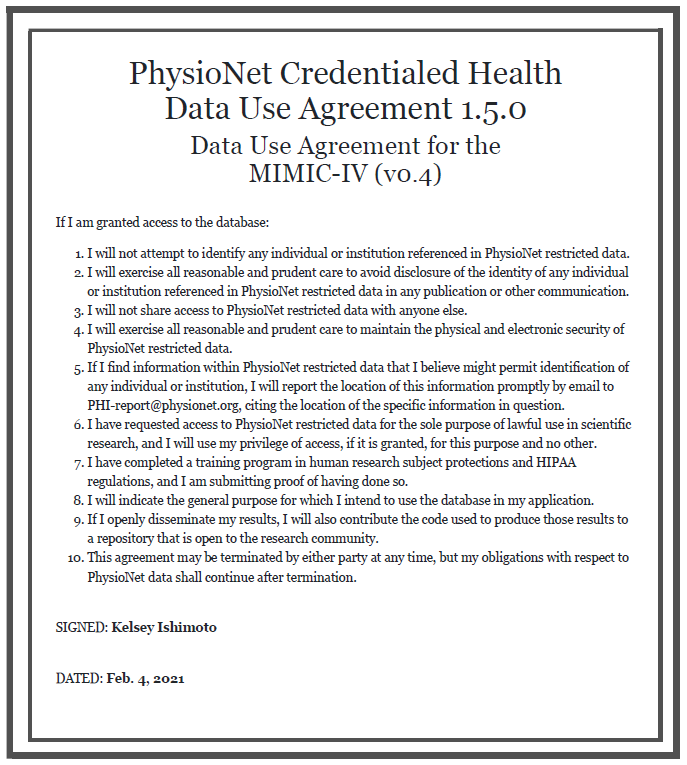

## Q2. `read.csv` (base R) vs `read_csv` (tidyverse) vs `fread` (data.table)

There are quite a few utilities in R for reading data files. Let us test the speed of reading a moderate sized compressed csv file, `admissions.csv.gz`, by three programs: `read.csv` in base R, `read_csv` in tidyverse, and `fread` in the popular data.table package. Is there any speed difference?

In this homework, we stick to the tidyverse.

### Solution:

```r
system.time(read.csv(str_c(mimic_path, "/core/admissions.csv.gz")))
```

```
##    user  system elapsed
##    9.25    0.20   10.03
```

```r
system.time(read_csv(str_c(mimic_path, "/core/admissions.csv.gz")))
```

```
##    user  system elapsed
##    2.97    1.08    4.19
```

```r
system.time(fread(str_c(mimic_path, "/core/admissions.csv.gz")))
```

```
##    user  system elapsed
##    1.31    0.28    2.25
```

The first time I ran this on the teaching server, the function `read.csv` took about 46 seconds to run on my machine. Whereas `read_csv` took only about 5 seconds to run. And `fread` took about 2 seconds to run. `fread` is the fastest read function, with `read_csv` close behind it, and `read.csv` much slower. On my local computer, the speed of these programs were different, but `fread` was still the fastest, and `read.csv` was still the slowest.

## Q3. ICU stays

`icustays.csv.gz` (https://mimic-iv.mit.edu/docs/datasets/icu/icustays/) contains data about Intensive Care Units (ICU) stays. Summarize following variables using appropriate numerics or graphs:

- how many unique `stay_id`?
- how many unique `subject_id`?
- length of ICU stay
- first ICU unit
- last ICU unit

### Solution:

First read in `icustays` data:

```r
icustays_tble <- read_csv(str_c(mimic_path, "/icu/icustays.csv.gz"))
print(icustays_tble, width = Inf)
```

```
## # A tibble: 69,619 x 8
##    subject_id  hadm_id  stay_id first_careunit
##         <dbl>    <dbl>    <dbl> <chr>
##  1   17823467 27561644 35964304 Coronary Care Unit (CCU)
##  2   15772648 26147926 39637383 Trauma SICU (TSICU)
##  3   13713711 25848902 36363748 Trauma SICU (TSICU)
##  4   13173210 22338446 38210858 Coronary Care Unit (CCU)
##  5   10213765 28522861 39765853 Trauma SICU (TSICU)
##  6   17530304 21776160 35848367 Trauma SICU (TSICU)
##  7   10297774 20364526 37788595 Coronary Care Unit (CCU)
##  8   16766597 21185791 39262919 Trauma SICU (TSICU)
##  9   17684317 28656350 36989766 Trauma SICU (TSICU)
## 10   15693895 21203492 34766377 Surgical Intensive Care Unit (SICU)
##    last_careunit                       intime              outtime
##    <chr>                               <dttm>              <dttm>
```

[output cut: 23 more lines]

- How many unique `stay_id`s?

```r
icustays_tble %>%
  distinct(stay_id) %>%
  nrow()
```

```
## [1] 69619
```

There are **69,619** unique `stay_id`s. It seems that each row is a unique ICU stay. (number of rows is the same as the number of rows of original tibble)

- How many unique `subject_id`s?

```r
icustays_tble %>%
  distinct(subject_id) %>%
  nrow()
```

```
## [1] 50048
```

There are **50,048** unique `subject_id`s. Since the number of unique `stay_id`s is greater than the number of unique `subject_id`s, one patient can have more than one ICU stays.

-length of ICU stays

```r
fivenum(icustays_tble$los)
```

```
## [1]   0.0346875   1.1338657   2.0610880   4.2021817 599.2496759
```

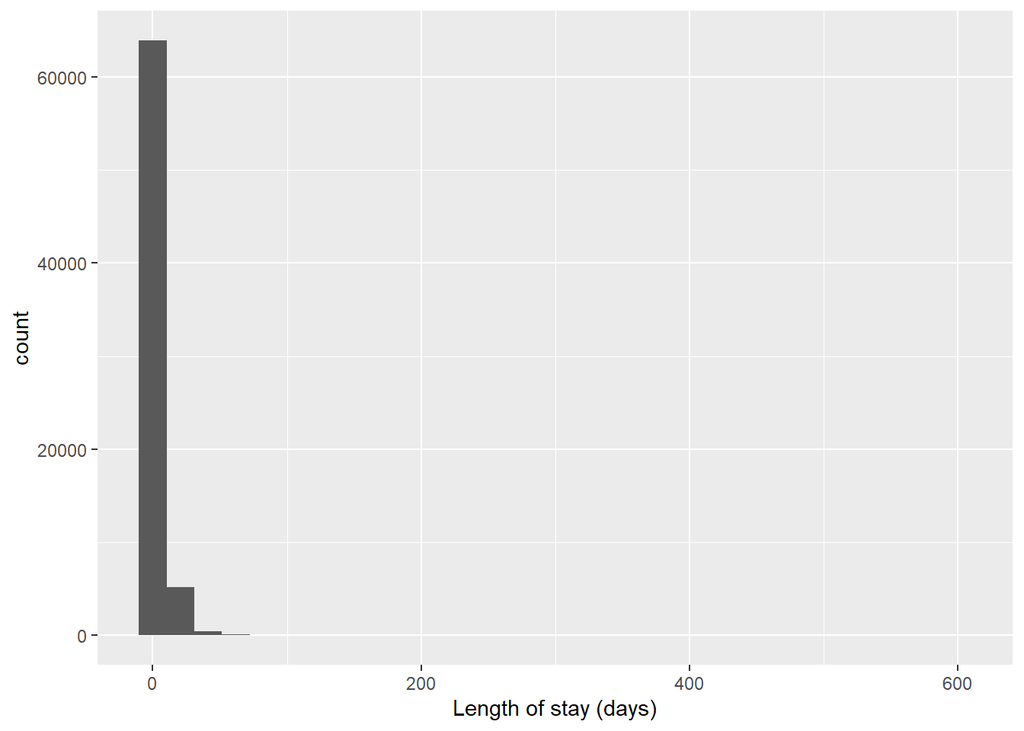

```r
icustays_tble %>%
  ggplot() +
  geom_histogram(mapping = aes(x = los)) +
  xlab("Length of stay (days)")
```

We can see from the histogram above that the length of ICU stays is very positively skewed. The median of the length of ICU stays is 2.06 days, and about half of our data lie between 1.13 days and 4.20 days. The minimum length of stay was less than half a day, and the maximum length of stay was almost 600 days.

- First ICU unit

```r
fculabs <- icustays_tble %>%
  select(first_careunit) %>%
  group_by(first_careunit) %>%
  summarise(prop = n()/nrow(.)) %>%
  mutate(percent = prop*100) %>%
  select(-prop)
```

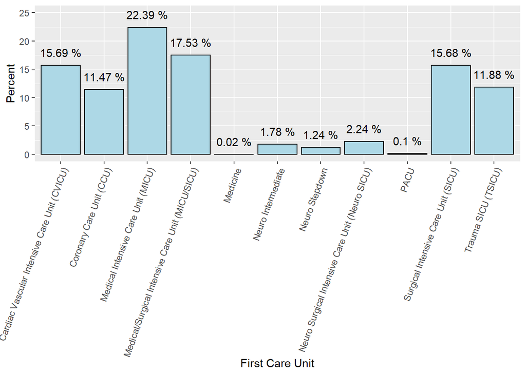

```r
fculabs$percent <- round(fculabs$percent, 2)

fculabs %>%
  ggplot(aes(x = first_careunit, y = percent, label = paste(percent, "%"))) +
  geom_col(color = "black", fill = "light blue") +
  xlab("First Care Unit") +
  ylab("Percent") +
  theme(axis.text.x = element_text(angle = 70, vjust = 1, hjust=1)) +
  geom_text(vjust = -1) +
  coord_cartesian(ylim = c(0, 25))
```

- Last ICU unit

```r
lculabs <- icustays_tble %>%
  select(last_careunit) %>%
  group_by(last_careunit) %>%
  summarise(prop = n()/nrow(.)) %>%
  mutate(percent = prop*100) %>%
  select(-prop)
```

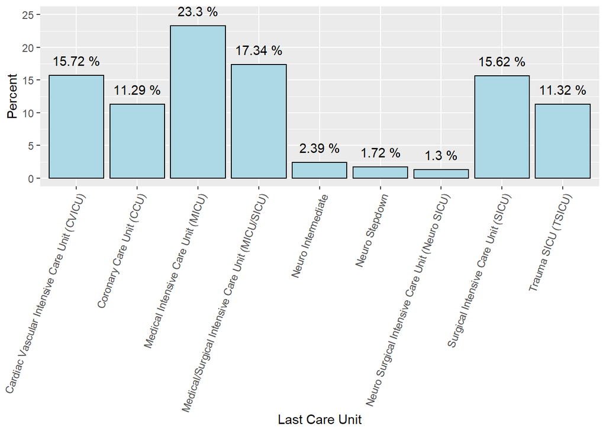

```r
lculabs$percent <- round(lculabs$percent, 2)

lculabs %>%
  ggplot(aes(x = last_careunit, y = percent, label = paste(percent, "%"))) +
  geom_col(color = "black", fill = "light blue") +
  xlab("Last Care Unit") +
  ylab("Percent") +
  theme(axis.text.x = element_text(angle = 70, vjust = 1, hjust=1)) +
  geom_text(vjust = -1) +
  coord_cartesian(ylim = c(0, 25))
```

The bar plot of the last care units is similar to the bar plot of first care units, perhaps indicating that the ICU patient usually does not transfer to a different ICU unit. However, Medicine and PACU that appear in the first care unit bar plot is not seen in the last care unit bar plot, indicating that maybe those ICU patients are then transferred to other ICU units before being discharged.

## Q4. `admission` data

Information of the patients admitted into hospital is available in `ADMISSION.csv.gz`. See https://mimic-iv.mit.edu/docs/datasets/core/admissions/ for details of each field in this file. Summarize following variables using appropriate graphs. Explain any patterns you observe.

- admission year
- admission month
- admission month day
- admission week day
- admission hour (anything unusual?)
- number of deaths in each year
- admission type
- number of admissions per patient
- admission location
- discharge location
- insurance
- language
- martial status
- ethnicity
- death

Note it is possible that one patient (uniquely identified by the `SUBJECT_ID`) is admitted into hospital multiple times. When summarizing some demographic information, it makes sense to summarize based on unique patients.

### Solution:

First read in the data:

```r
admissions_tble <- read_csv(str_c(mimic_path, "/core/admissions.csv.gz"))
```

As we have seen before, the same patient could have several hospital stays. So first, I want to decide which variables I will need to only look at distinct `subject_id`s for. In order to do this, I want to look at a sample of the data:

```r
admissions_tble %>%
  filter(hospital_expire_flag == 1) %>%
  head()
```

```
## # A tibble: 6 x 15
##   subject_id hadm_id admittime           dischtime           deathtime
##        <dbl>   <dbl> <dttm>              <dttm>              <dttm>
## 1   12727163  2.92e7 2140-06-12 22:04:00 2140-06-24 14:45:00 2140-06-24 14:45:00
## 2   14536465  2.01e7 2185-01-08 02:53:00 2185-01-09 04:06:00 2185-01-09 04:06:00
## 3   19645794  2.79e7 2170-10-06 07:35:00 2170-10-06 18:12:00 2170-10-06 18:12:00
## 4   16441855  2.52e7 2189-07-12 14:10:00 2189-07-12 15:10:00 2189-07-12 15:10:00
## 5   11475290  2.60e7 2156-02-08 00:59:00 2156-02-08 13:43:00 2156-02-08 13:43:00
## 6   11707036  2.87e7 2149-01-21 04:24:00 2149-01-21 19:20:00 2149-01-21 19:20:00
## # ... with 10 more variables: admission_type <chr>, admission_location <chr>,
## #   discharge_location <chr>, insurance <chr>, language <chr>,
## #   marital_status <chr>, ethnicity <chr>, edregtime <dttm>, edouttime <dttm>,
## #   hospital_expire_flag <dbl>
```

```r
# 16441855, 14536465, 11475290: different subject ids that I looked at
admissions_tble %>%
  select(subject_id, admittime, dischtime,
         admission_location, discharge_location) %>%
  filter(subject_id == 11707036) %>%
  arrange(admittime) %>%
  print(width = Inf)
```

```
## # A tibble: 1 x 5
##   subject_id admittime           dischtime           admission_location
##        <dbl> <dttm>              <dttm>              <chr>
## 1   11707036 2149-01-21 04:24:00 2149-01-21 19:20:00 TRANSFER FROM HOSPITAL
##   discharge_location
##   <chr>
## 1 <NA>
```

A single patient may have been admitted to the hospital several times, but sometimes, the second admission is just that patient being transferred to another hospital department, and other times it is the case that patient is discharged home and then they end up at the hospital again. Since this is the case, I will include the whole dataset for most analysis other than demographic information. For the summary of death, I will also summarize by unique patients.

- Admission Year

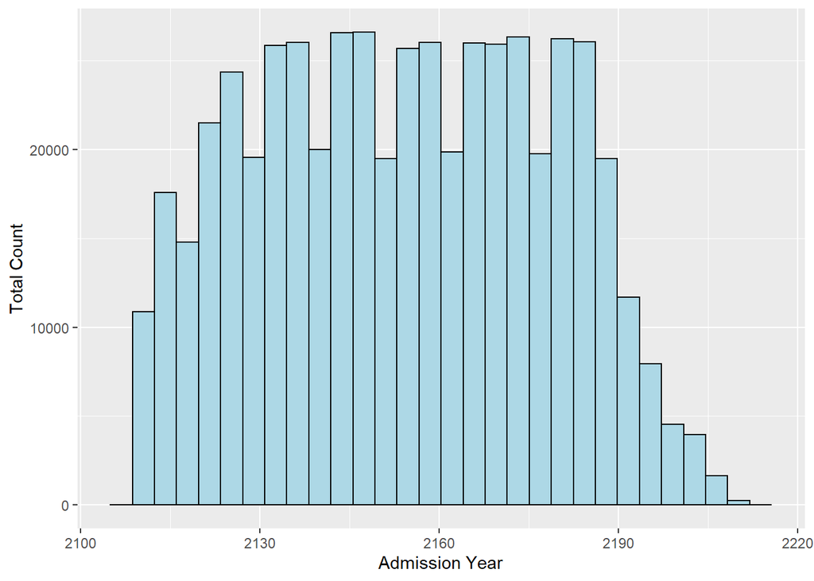

```r
admissions_tble %>%
  ggplot(aes(x = year(admittime))) +
  geom_histogram(aes(y = ..count..), bins = 30,
                 color = "black", fill = "light blue") +
  xlab("Admission Year") +
  ylab("Total Count")
```

- Admission Month

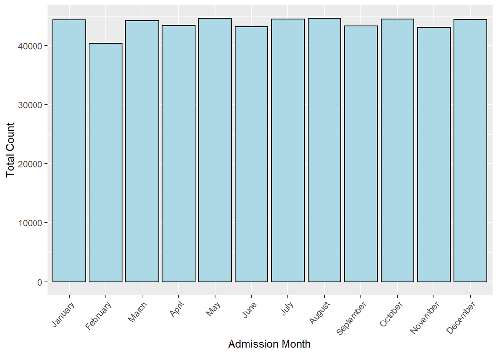

```r
admissions_tble %>%
  ggplot(aes(x = month(admittime, labe = TRUE, abbr = FALSE))) +
  geom_bar(color = "black", fill = "light blue") +
  xlab("Admission Month") +
  ylab("Total Count") +
  theme(axis.text.x = element_text(angle = 50, vjust = 1, hjust=1))
```

- Admission Month Day

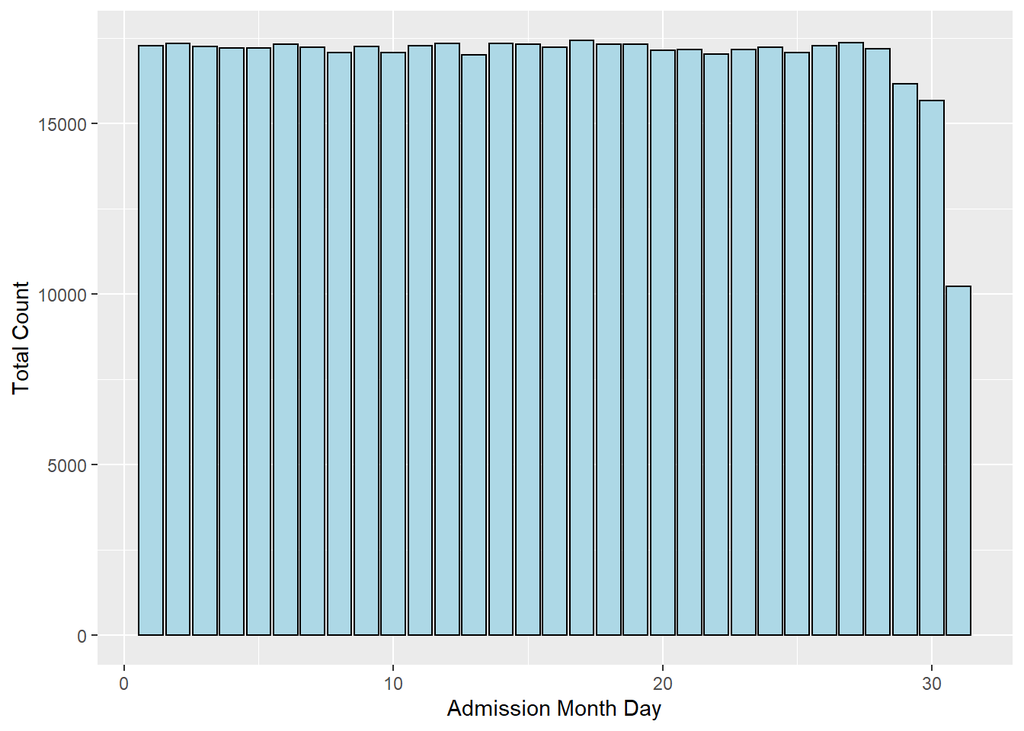

```r
admissions_tble %>%
  ggplot(aes(x = mday(admittime))) +
  geom_bar(color = "black", fill = "light blue") +
  xlab("Admission Month Day") +
  ylab("Total Count")
```

We can see that there are less admissions at hte end of the month. This is because not all months have a 31st day, and similarly, the month of February is short; it never has the 30th or 31st day, and only has the 29th day every fourth year. This is reflected in the above graph where the 29th, 30th, and 31st days have less admissions than the rest of the month days. For the other days, it seems that other days have about the same admission count.

- Admission Week Day

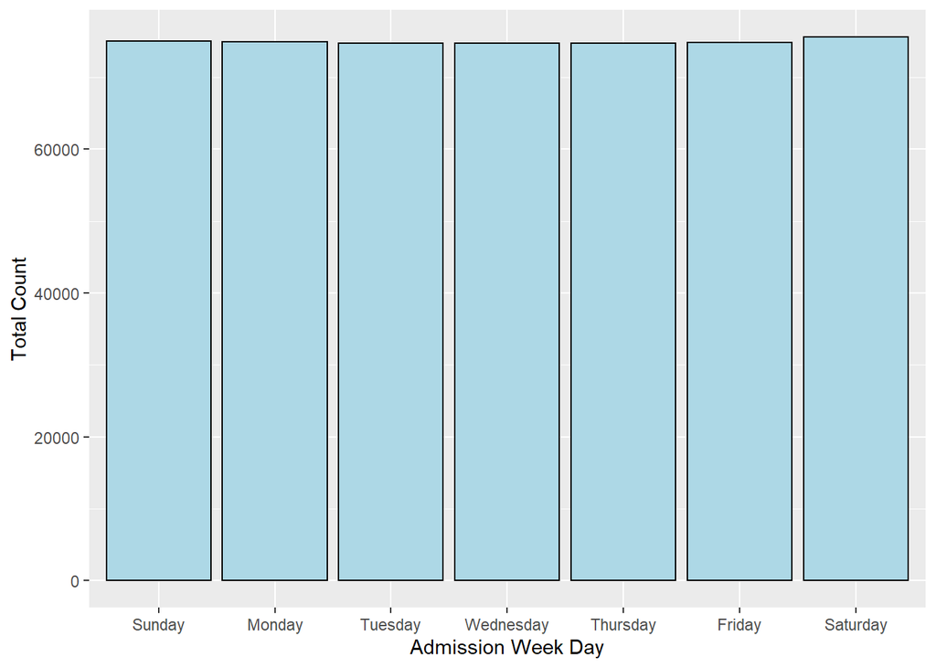

```r
admissions_tble %>%
  ggplot(aes(x = wday(admittime, label = TRUE, abbr = FALSE))) +
  geom_bar(color = "black", fill = "light blue") +
  xlab("Admission Week Day") +
  ylab("Total Count")
```

All the week days have a similar count of patients, indicating that there seems to be a uniform distribution of admissions across week days.

- Admission Hour (anything unusual?)

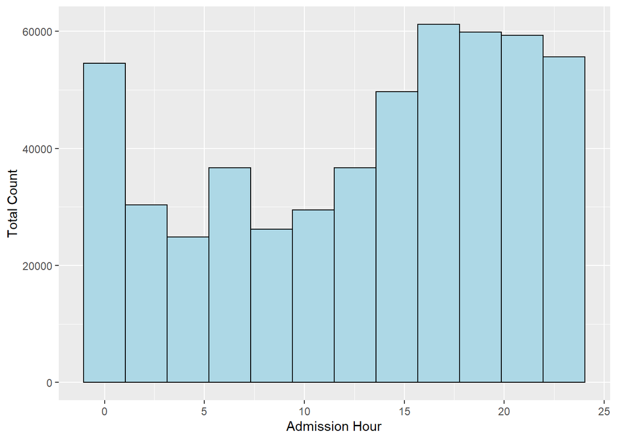

```r
admissions_tble %>%
  ggplot(aes(x = hour(admittime))) +
  geom_histogram(aes(y = ..count..), bins = 12,
                 color = "black", fill = "light blue") +
  xlab("Admission Hour") +
  ylab("Total Count")
```

There seems to be an unusually large number of patients that were admitted at midnight. This might be the time the hospital wrote down when the actual admission time was not known. There is also a peak of admission hour around 7am. This might be because that is when people wake up and find something wrong with themselves or their family member. Similarly, there is another peak of admissions in the evening. This might be that people found something wrong with themselves but didn’t go to the hospital to get admitted until after their work was over, or didn’t find their family member at home until they got off of work.

- Number of Deaths in Each Year

First I’m going to check whether the number of deaths is the same when we make the calculations with `deathtime` not missing and when we use `hospital_expire_flag` = 1

```r
admissions_tble %>%
  summarise(flagdead = sum(hospital_expire_flag),
            timedead = sum(!is.na(deathtime)))
```

```
## # A tibble: 1 x 2
##   flagdead timedead
##      <dbl>    <int>
## 1     9369     9356
```

We can see that the results are not the same when we use these two different variables. Using the `hospital_expire_flag`, there seems to be more people who did not survive their hospital stay.

```r
admissions_tble %>%
  select(dischtime, deathtime, hospital_expire_flag) %>%
  filter(hospital_expire_flag == 1 & is.na(deathtime))
```

```
## # A tibble: 13 x 3
##    dischtime           deathtime           hospital_expire_flag
##    <dttm>              <dttm>                             <dbl>
##  1 2154-06-07 17:00:00 NA                                     1
##  2 2110-12-27 18:50:00 NA                                     1
##  3 2203-03-29 15:22:00 NA                                     1
##  4 2184-07-16 21:48:00 NA                                     1
##  5 2150-12-09 16:59:00 NA                                     1
##  6 2150-12-07 16:59:00 NA                                     1
##  7 2121-05-22 17:30:00 NA                                     1
##  8 2148-08-24 12:36:00 NA                                     1
##  9 2172-06-05 09:00:00 NA                                     1
## 10 2184-08-12 12:52:00 NA                                     1
## 11 2131-03-10 17:05:00 NA                                     1
## 12 2176-04-24 20:22:00 NA                                     1
## 13 2129-02-09 06:51:00 NA                                     1
```

Reading the documentation of the MIMIC-IV data, it says, “Note that `deathtime` is only present if the patient died in-hospital, and is almost always the same as the patient’s `dischtime`. However, there can be some discrepancies due to typographical errors.” For all the data points where `deathtime` is missing but `hospital_expire_flag` = 1 (indicating the patient died in the hospital), a discharge time still exists, and from the documentation, it seems that time of death is usually agrees with discharge time unless there are typographical errors. It could be that the hospital worker only wrote down the discharge time assuming that people would know that would be the same time of death for patients who did not survive their hospital stay. For this reason, I will use `hospital_expire_flag` as the indicator of death.

```r
yeardeaths <- admissions_tble %>%
  group_by(year(dischtime)) %>%
  summarise(dead = sum(hospital_expire_flag))
```

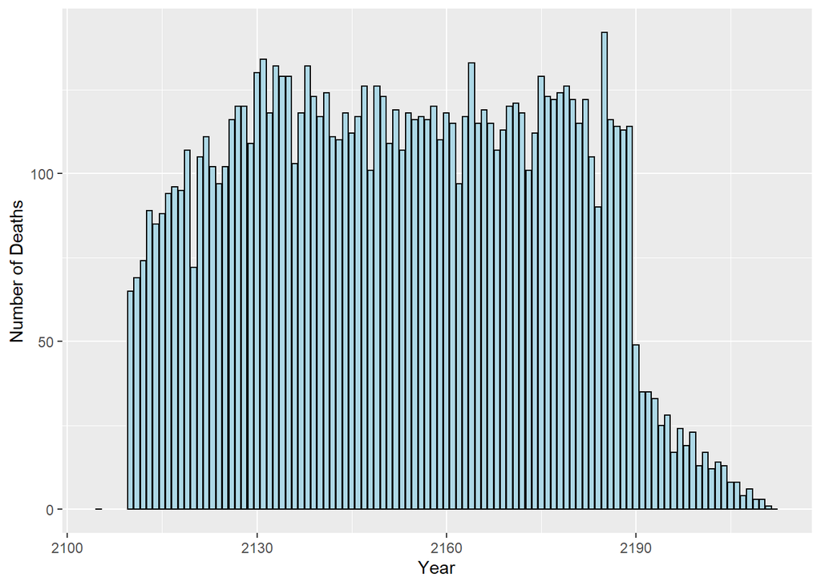

```r
names(yeardeaths) <- c('year', 'dead')

yeardeaths %>%
  ggplot(aes(x = year, y = dead)) +
  geom_col(color = "black", fill = "light blue") +
  xlab("Year") +
  ylab("Number of Deaths")
```

The shape of this graph is similar to the shape of the admission year graph. Indicating that the rate of deaths per admissions per year is around the same across the years.

- Admission Type

```r
adtypelabs <- admissions_tble %>%
  select(admission_type) %>%
  group_by(admission_type) %>%
  summarise(prop = n()/nrow(.)) %>%
  mutate(percent = prop*100) %>%
  select(-prop)
```

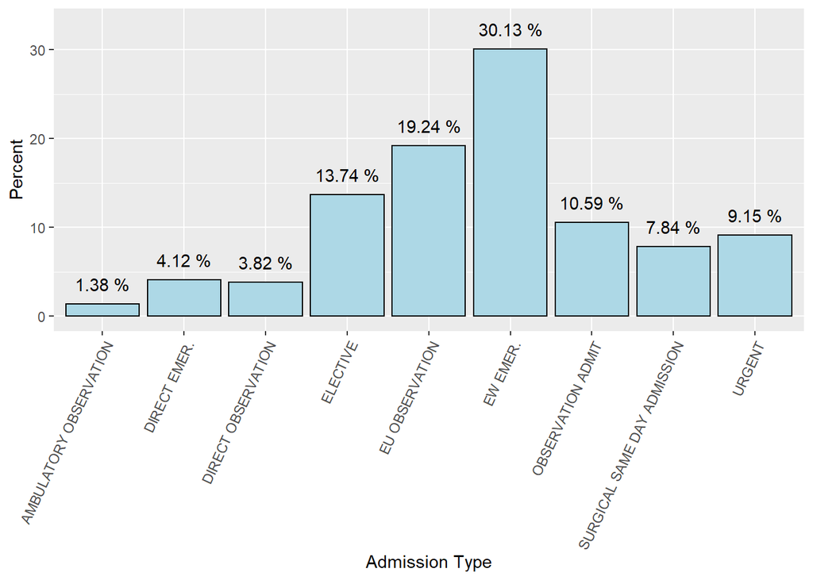

```r
adtypelabs$percent <- round(adtypelabs$percent, 2)

adtypelabs %>%
  ggplot(aes(x = admission_type, y = percent, label = paste(percent, "%"))) +
  geom_col(color = "black", fill = "light blue") +
  xlab("Admission Type") +
  ylab("Percent") +
  theme(axis.text.x = element_text(angle = 65, vjust = 1, hjust=1)) +
  geom_text(vjust = -1) +
  coord_cartesian(ylim = c(0, 33))
```

Most patients seemed to have been admitted through Elective, EU Observation, or EW Emergency.

- Number of Admissions per Patient

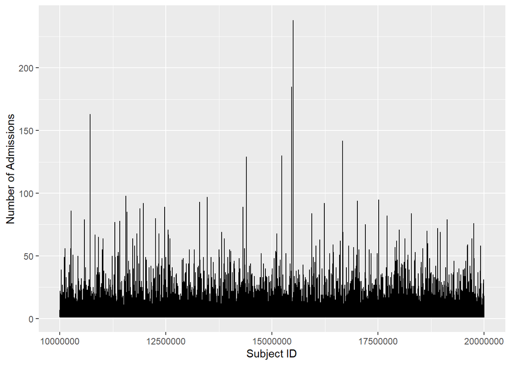

```r
admissions_tble %>%
  count(subject_id) %>%
  ggplot(aes(x = subject_id, y = n)) +
  geom_line() +
  xlab("Subject ID") +
  ylab("Number of Admissions")
```

Most patients seemed to have been only admitted a few times while other patients were admitted dozens of times, and other patients were admitted over a hundred times. As we have investigated before, “admissions” also refers to times when patients are transferred to another hospital department, which can account for some of the multiple hospital admissions, but the higher number of admissions seems very high.

- Admission Location

```r
adloclabs <- admissions_tble %>%
  select(admission_location) %>%
  group_by(admission_location) %>%
  summarise(prop = n()/nrow(.)) %>%
  mutate(percent = prop*100) %>%
  select(-prop)
```

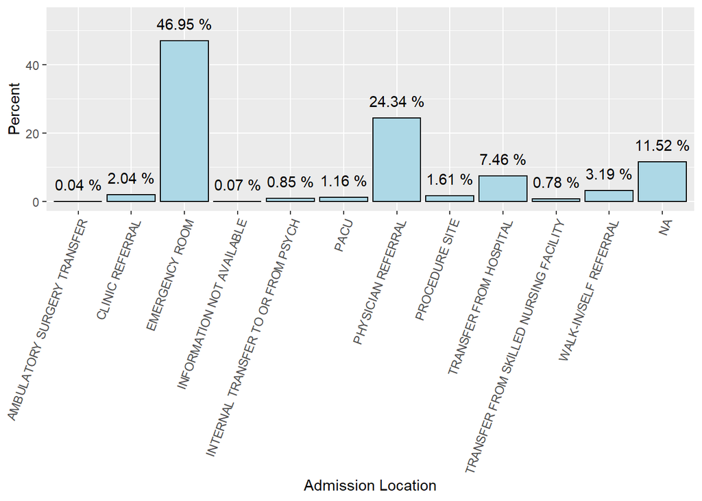

```r
adloclabs$percent <- round(adloclabs$percent, 2)

adloclabs %>%
  ggplot(aes(x = admission_location, y = percent,
             label = paste(percent, "%"))) +
  geom_col(color = "black", fill = "light blue") +
  xlab("Admission Location") +
  ylab("Percent") +
  theme(axis.text.x = element_text(angle = 70, vjust = 1, hjust=1)) +
  geom_text(vjust = -1) +
  coord_cartesian(ylim = c(0, 54))
```

- Discharge Location

```r
disloclabs <- admissions_tble %>%
  select(discharge_location) %>%
  group_by(discharge_location) %>%
  summarise(prop = n()/nrow(.)) %>%
  mutate(percent = prop*100) %>%
  select(-prop)
```

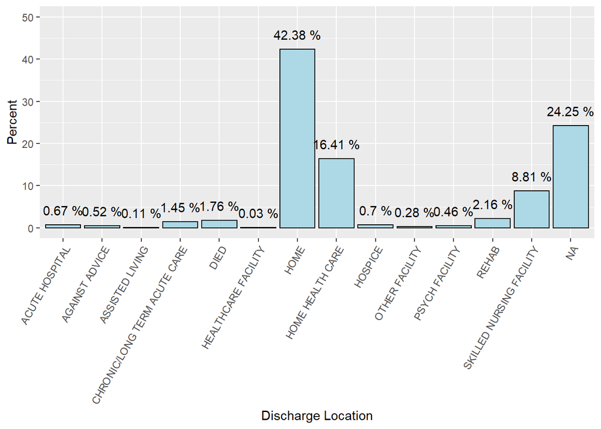

```r
disloclabs$percent <- round(disloclabs$percent, 2)

disloclabs %>%
  ggplot(aes(x = discharge_location, y = percent,
             label = paste(percent, "%"))) +
  geom_col(color = "black", fill = "light blue") +
  xlab("Discharge Location") +
  ylab("Percent") +
  theme(axis.text.x = element_text(angle = 60, vjust = 1, hjust=1)) +
  geom_text(vjust = -1) +
  coord_cartesian(ylim = c(0, 50))
```

- Insurance

Each patient should have the same insurance across all of their hospital stays, so I chose to only look at unique `subject_id`s for this summary of `insurance`.

```r
inslabs <- admissions_tble %>%
  distinct(., subject_id, .keep_all = TRUE) %>%
  select(insurance) %>%
  group_by(insurance) %>%
  summarise(prop = n()/nrow(.)) %>%
  mutate(percent = prop*100) %>%
  select(-prop)
```

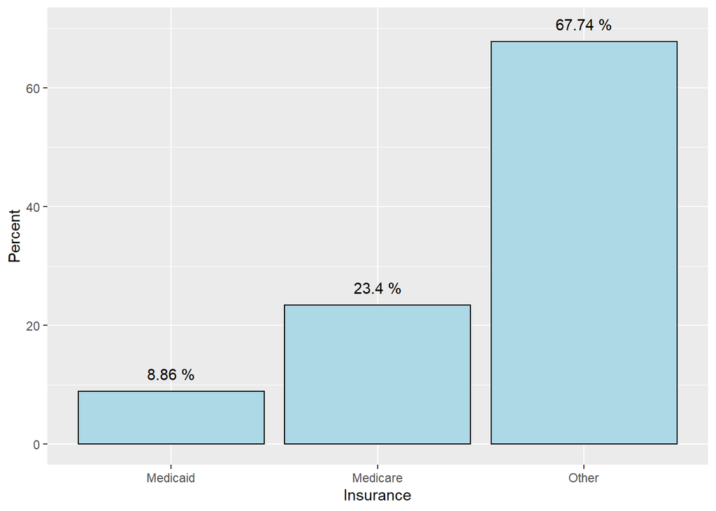

```r
inslabs$percent <- round(inslabs$percent, 2)

inslabs %>%
  ggplot(aes(x = insurance, y = percent, label = paste(percent, "%"))) +
  geom_col(color = "black", fill = "light blue") +
  xlab("Insurance") +
  ylab("Percent") +
  geom_text(vjust = -1) +
  coord_cartesian(ylim = c(0, 70))
```

More than half the patients (67.74%) had insurance other than Medicaid and Medicare.

- Language

Again, only looking at unique `subject_id`s.

```r
langlabs <- admissions_tble %>%
  distinct(., subject_id, .keep_all = TRUE) %>%
  select(language) %>%
  group_by(language) %>%
  summarise(prop = n()/nrow(.)) %>%
  mutate(percent = prop*100) %>%
  select(-prop)
```

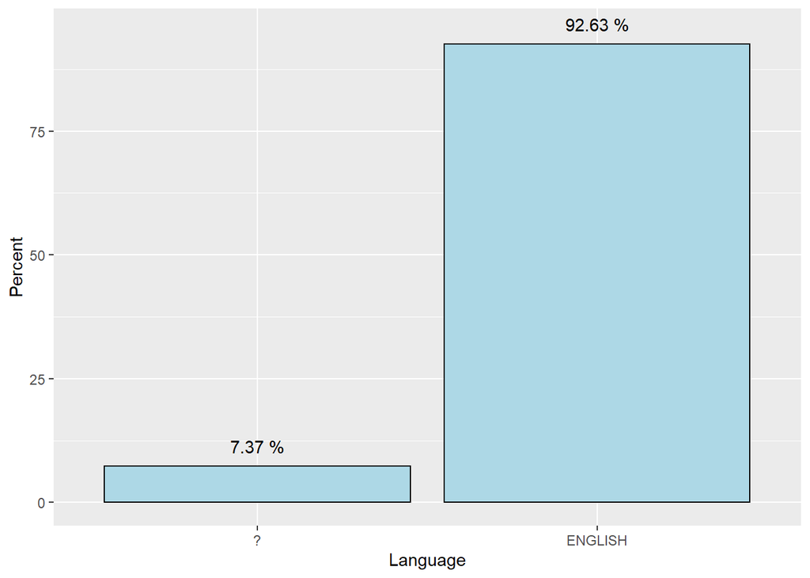

```r
langlabs$percent <- round(langlabs$percent, 2)

langlabs %>%
  ggplot(aes(x = language, y = percent, label = paste(percent, "%"))) +
  geom_col(color = "black", fill = "light blue") +
  xlab("Language") +
  ylab("Percent") +
  geom_text(vjust = -1) +
  coord_cartesian(ylim = c(0, 95))
```

The overwhelming majority (92.63%) of patients spoke English.

- Martial Status:

Again, only looking at unique `subject_id`s

```r
marlabs <- admissions_tble %>%
  distinct(., subject_id, .keep_all = TRUE) %>%
  select(marital_status) %>%
  group_by(marital_status) %>%
  summarise(prop = n()/nrow(.)) %>%
  mutate(percent = prop*100) %>%
  select(-prop)
```

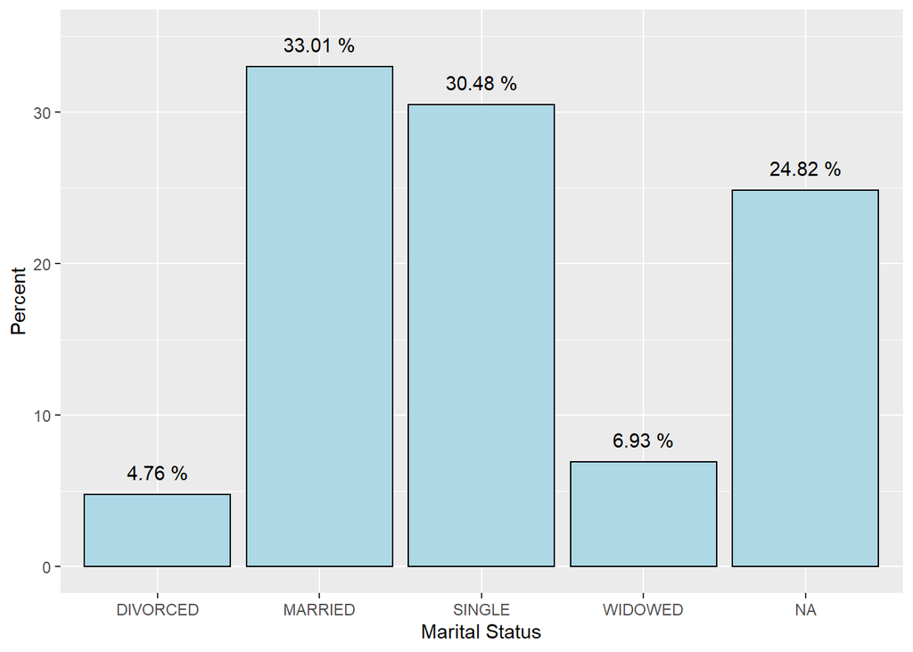

```r
marlabs$percent <- round(marlabs$percent, 2)

marlabs %>%
  ggplot(aes(x = marital_status, y = percent, label = paste(percent, "%"))) +
  geom_col(color = "black", fill = "light blue") +
  xlab("Marital Status") +
  ylab("Percent") +
  geom_text(vjust = -1) +
  coord_cartesian(ylim = c(0, 35))
```

Most patients were either married or single. But also, a lot of patients were listed as `NA` which I’m not sure what that means. It could be that the patient was too young to be married or that the marital status was unknown.

- Ethnicity

```r
ethlabs <- admissions_tble %>%
  distinct(., subject_id, .keep_all = TRUE) %>%
  select(ethnicity) %>%
  group_by(ethnicity) %>%
  summarise(prop = n()/nrow(.)) %>%
  mutate(percent = prop*100) %>%
  select(-prop)
```

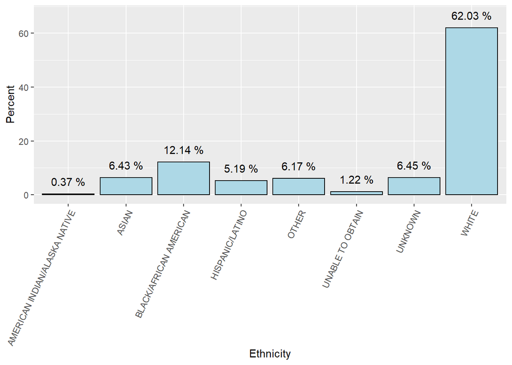

```r
ethlabs$percent <- round(ethlabs$percent, 2)

ethlabs %>%
  ggplot(aes(x = ethnicity, y = percent, label = paste(percent, "%"))) +
  geom_col(color = "black", fill = "light blue") +
  xlab("Ethnicity") +
  ylab("Percent") +
  geom_text(vjust = -1) +
  coord_cartesian(ylim = c(0, 67)) +
  theme(axis.text.x = element_text(angle = 65, vjust = 1, hjust = 1))
```

More than half the patients (62.03%) were white.

- Death

```r
admissions_tble %>%
  summarize(death_count = sum(hospital_expire_flag))
```

```
## # A tibble: 1 x 1
##   death_count
##         <dbl>
## 1        9369
```

```r
#9369 patients died in the hospital

admissions_tble %>%
  distinct(., subject_id) %>%
  nrow()
```

```
## [1] 257366
```

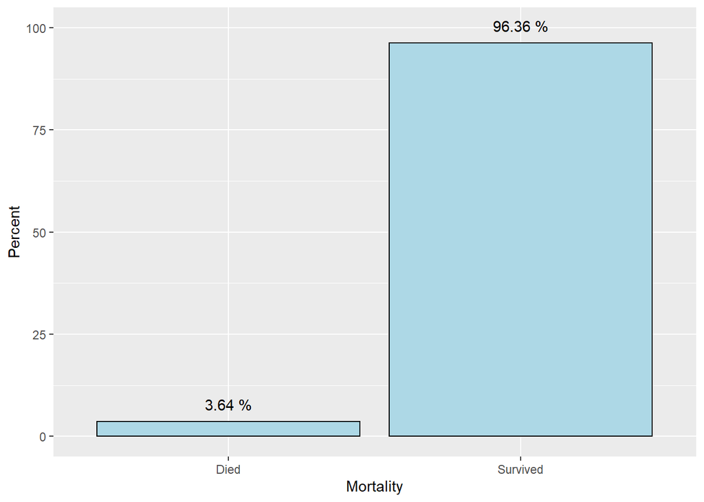

```r
# there are 257,366 unique patients total

mort <- c("Died", "Survived")
percent <- round(c(9369/257366*100, (257366-9369)/257366*100), 2)

ggplot(mapping = aes(x = mort, y = percent, label = paste(percent, "%")))+
  geom_col(color = "black", fill = "light blue")+
  xlab("Mortality") +
  ylab("Percent") +
  geom_text(vjust = -1) +
  coord_cartesian(ylim = c(0, 100))
```

The total number of unique patients is 257,366 people. Of those patients, 9,369 (3.64%) of them ended up dying in the hospital. But as we can see in the graph, the overwhelming majority of patients survived (96.36%).

## Q5. `patient` data

Explore `patients.csv.gz` (https://mimic-iv.mit.edu/docs/datasets/core/patients/) and summarize following variables using appropriate numerics and graphs:

- `gender`
- `anchor_age` (explain pattern you see)

### Solution:

- meaning of `anchor_age`: `anchor_age` is the age of a patient in the provided `anchor_year` (these measures were taken in order to de-identify the data)

```r
patients_tble <- read_csv(str_c(mimic_path, "/core/patients.csv.gz"))
print(patients_tble, width = Inf)
```

```
## # A tibble: 383,220 x 6
##    subject_id gender anchor_age anchor_year anchor_year_group dod
##         <dbl> <chr>       <dbl>       <dbl> <chr>             <lgl>
##  1   10002723 F               0        2128 2017 - 2019       NA
##  2   10003939 M               0        2184 2008 - 2010       NA
##  3   10004222 M               0        2161 2014 - 2016       NA
##  4   10005325 F               0        2154 2011 - 2013       NA
##  5   10007338 F               0        2153 2017 - 2019       NA
##  6   10008101 M               0        2142 2008 - 2010       NA
##  7   10009872 F               0        2168 2014 - 2016       NA
##  8   10011333 F               0        2132 2014 - 2016       NA
##  9   10011879 M               0        2158 2014 - 2016       NA
## 10   10012663 F               0        2171 2011 - 2013       NA
## # ... with 383,210 more rows
```

- Gender

```r
genlabs <- patients_tble %>%
  select(gender) %>%
  group_by(gender) %>%
  summarise(prop = n()/nrow(.)) %>%
  mutate(percent = prop*100) %>%
  select(-prop)
```

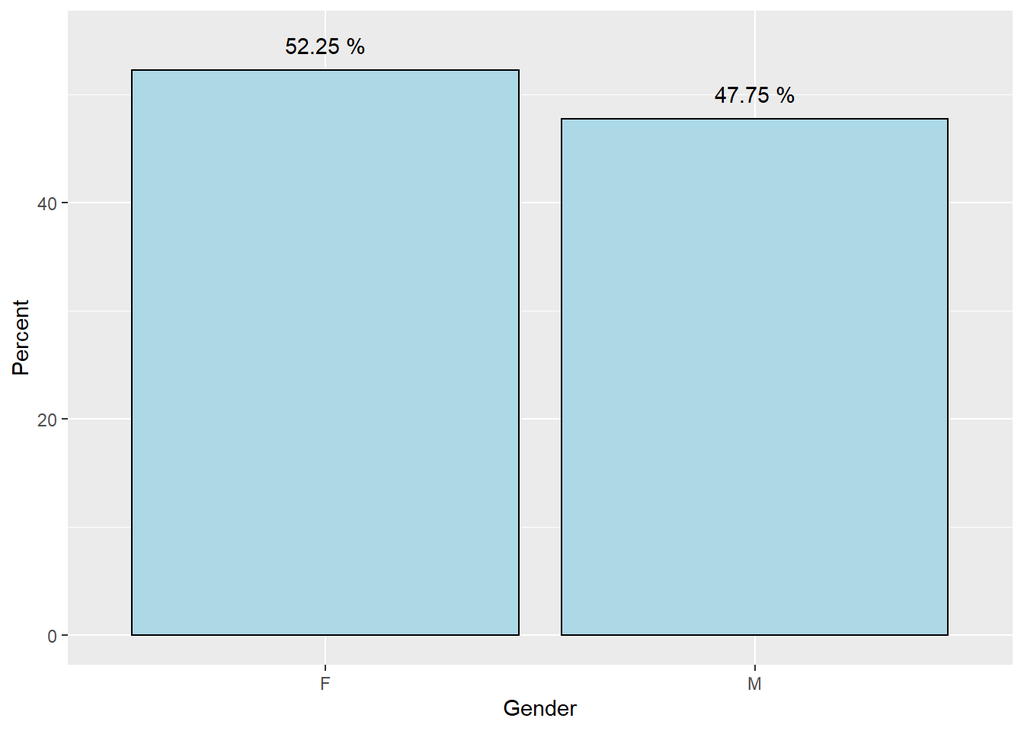

```r
genlabs$percent <- round(genlabs$percent, 2)

genlabs %>%
  ggplot(aes(x = gender, y = percent, label = paste(percent, "%"))) +
  geom_col(color = "black", fill = "light blue") +
  xlab("Gender") +
  ylab("Percent") +
  geom_text(vjust = -1) +
  coord_cartesian(ylim = c(0, 55))
```

The genders of the patients are split fairly evenly between male and female.

- Anchor Age

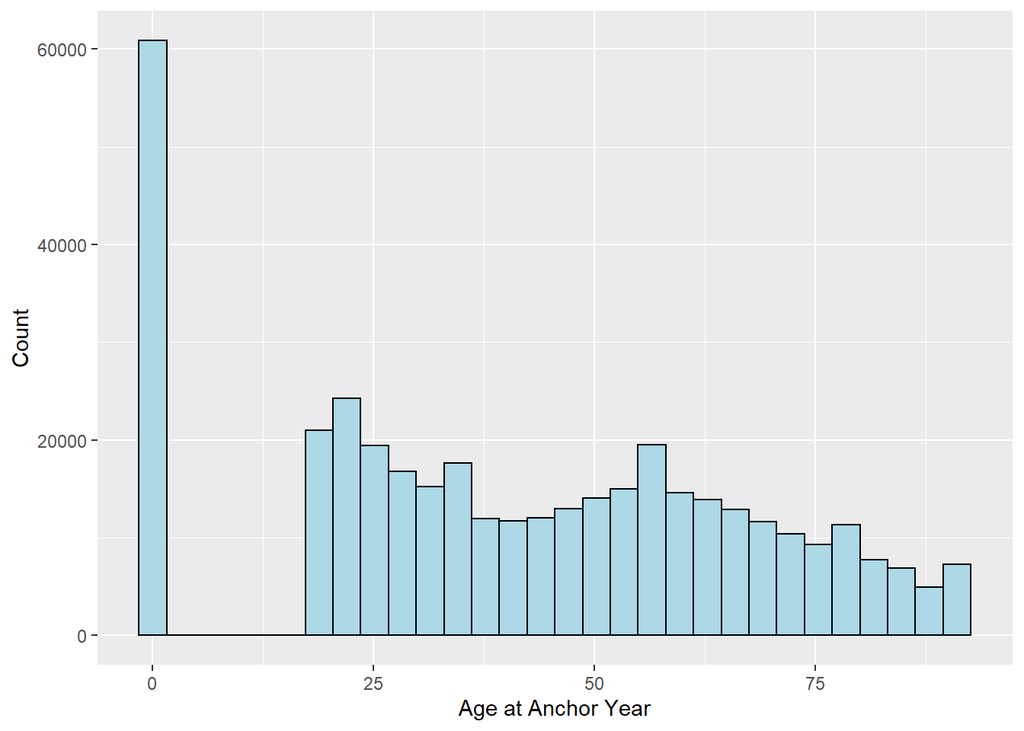

```r
patients_tble %>%
  ggplot(aes(x = anchor_age)) +
  geom_histogram(color = "black", fill = "light blue", bin = 20) +
  xlab("Age at Anchor Year") +
  ylab("Count")
```

## Q6. Lab results

`labevents.csv.gz` (https://mimic-iv.mit.edu/docs/datasets/hosp/labevents/) contains all laboratory measurements for patients.

We are interested in the lab measurements of creatinine (50912), potassium (50971), sodium (50983), chloride (50902), bicarbonate (50882), hematocrit (51221), white blood cell count (51301), glucose (50931), magnesium (50960), calcium (50893), and lactate (50813). Find the itemids of these lab measurements from d_labitems.csv.gz and retrieve a subset of labevents.csv.gz only containing these items.

### Solution:

So first we want to load in our lab events data. We only need a few variables, and we only need the `subject_id`s that match the subset of `subject_id`s in the `icustays` file.

Code from Dr. Zhou:

```r
if (!file.exists("labevents_icustays.csv.gz")) {
  labevents_tble <- fread(str_c(mimic_path, "/hosp/labevents.csv.gz"),
                          select = c("subject_id", "hadm_id", "itemid",
                                     "charttime", "valuenum"),
                          nThread = 4)

  labevents_tble %>%
    semi_join(icustays_tble, by = c("subject_id", "hadm_id")) %>%
    fwrite("labevents_icustays.csv.gz", nThread = 4)
}
```

```r
labevents1 <- as_tibble(fread("labevents_icustays.csv.gz"))
print(labevents1, width = Inf)
```

```
## # A tibble: 26,941,051 x 5
##    subject_id  hadm_id itemid charttime           valuenum
##         <int>    <int>  <int> <chr>                  <dbl>
##  1   12457441 21673651  50861 2135-08-16 23:45:00     25
##  2   12457441 21673651  50862 2135-08-16 23:45:00      3.4
##  3   12457441 21673651  50863 2135-08-16 23:45:00    103
##  4   12457441 21673651  50868 2135-08-16 23:45:00     13
##  5   12457441 21673651  50878 2135-08-16 23:45:00    104
##  6   12457441 21673651  50882 2135-08-16 23:45:00     28
##  7   12457441 21673651  50883 2135-08-16 23:45:00      2.1
##  8   12457441 21673651  50884 2135-08-16 23:45:00      2
##  9   12457441 21673651  50885 2135-08-16 23:45:00      4.1
## 10   12457441 21673651  50893 2135-08-16 23:45:00      7.5
## # ... with 26,941,041 more rows
```

Now we only want some lab item ids, so first I will read in the lab item dictionary:

```r
dlabitmes_tble <-
  read_csv(str_c(mimic_path, "/hosp/d_labitems.csv.gz")) %>%
  print(width = Inf)
```

```
## # A tibble: 1,625 x 5
##    itemid label                     fluid            category   loinc_code
##     <dbl> <chr>                     <chr>            <chr>      <chr>
##  1  51898 <NA>                      Other Body Fluid Chemistry  <NA>
##  2  51532 11-Deoxycorticosterone    Blood            Chemistry  <NA>
##  3  51952 17-Hydroxycorticosteroids Urine            Chemistry  <NA>
##  4  51953 17-Ketosteroids, Urine    Urine            Chemistry  <NA>
##  5  52063 24 Hr                     Blood            Hematology <NA>
##  6  51066 24 hr Calcium             Urine            Chemistry  <NA>
##  7  51067 24 hr Creatinine          Urine            Chemistry  <NA>
##  8  51068 24 hr Protein             Urine            Chemistry  <NA>
##  9  50853 25-OH Vitamin D           Blood            Chemistry  <NA>
## 10  51533 3t                        Blood            Chemistry  <NA>
## # ... with 1,615 more rows
```

Creating a matrix that matches the subset of item id’s that we want with their labels.

```r
itemids <- c(50912, 50971, 50983, 50902, 50882, 51221, 51301, 50931, 50960, 50893, 50813)

labels <- matrix(rep(0, 22), nrow = 11)
j <- 1

for (i in itemids){
  labels[j, 1] <- i
  labels[j, 2] <- dlabitmes_tble$label[dlabitmes_tble$itemid == i]
  j <- j + 1
}
print(labels)
```

```
##       [,1]    [,2]
##  [1,] "50912" "Creatinine"
##  [2,] "50971" "Potassium"
##  [3,] "50983" "Sodium"
##  [4,] "50902" "Chloride"
##  [5,] "50882" "Bicarbonate"
##  [6,] "51221" "Hematocrit"
##  [7,] "51301" "White Blood Cells"
##  [8,] "50931" "Glucose"
##  [9,] "50960" "Magnesium"
## [10,] "50893" "Calcium, Total"
## [11,] "50813" "Lactate"
```

```r
labevents_tble <- labevents1 %>%
  filter(itemid %in% itemids) %>%
  arrange(subject_id) %>%
  mutate(charttime = ymd_hms(charttime)) %>%
  print(labevents_tble, width = Inf)
```

```
## # A tibble: 8,021,352 x 5
##    subject_id  hadm_id itemid charttime           valuenum
##         <int>    <int>  <int> <dttm>                 <dbl>
##  1   10000032 29079034  50931 2180-07-25 04:45:00    121
##  2   10000032 29079034  50931 2180-07-24 06:35:00    107
##  3   10000032 29079034  50931 2180-07-23 21:45:00    115
##  4   10000032 29079034  50882 2180-07-23 21:45:00     21
##  5   10000032 29079034  50893 2180-07-23 21:45:00      9.3
##  6   10000032 29079034  50902 2180-07-23 21:45:00    102
##  7   10000032 29079034  50912 2180-07-23 21:45:00      0.5
##  8   10000032 29079034  50960 2180-07-23 21:45:00      2.3
##  9   10000032 29079034  50971 2180-07-23 21:45:00      4.7
## 10   10000032 29079034  50983 2180-07-23 21:45:00    132
## # ... with 8,021,342 more rows
```

Checking my work with the filtered data file from Dr. Zhou:

```r
labevents2 <- as_tibble(fread(str_c(mimic_path2,
                                    "/labevents_filtered_itemid.csv.gz")))

names(labevents2) <- c("subject_id", "hadm_id", "itemid",
                       "charttime", "valuenum")

labevents2 %>%
  arrange(subject_id) %>%
  print(labevents2, width = Inf)
```

```
## # A tibble: 30,773,355 x 5
##    subject_id  hadm_id itemid charttime           valuenum
##         <int>    <int>  <int> <chr>                  <dbl>
##  1   10000019 25058216  51221 2129-05-21 21:10:00     52.6
##  2   10000019 25058216  51301 2129-05-21 21:10:00     20.3
##  3   10000032       NA  50813 2180-07-23 06:48:00      1.6
##  4   10000032       NA  50971 2180-07-30 09:30:00      5.3
##  5   10000032 25742920  50931 2180-08-07 06:15:00     87
##  6   10000032 25742920  50931 2180-08-07 00:59:00    102
##  7   10000032       NA  50931 2180-08-10 12:00:00    155
##  8   10000032 25742920  50931 2180-08-06 06:36:00     95
##  9   10000032       NA  50931 2180-03-23 11:51:00     95
## 10   10000032       NA  50931 2180-08-05 21:20:00    118
## # ... with 30,773,345 more rows
```

```r
labevents2 %>%
  semi_join(icustays_tble, by = c("subject_id", "hadm_id")) %>%
  arrange(subject_id) %>%
  mutate(charttime = ymd_hms(charttime)) %>%
  print()
```

```
## # A tibble: 8,021,352 x 5
##    subject_id  hadm_id itemid charttime           valuenum
##         <int>    <int>  <int> <dttm>                 <dbl>
##  1   10000032 29079034  50931 2180-07-25 04:45:00    121
##  2   10000032 29079034  50931 2180-07-24 06:35:00    107
##  3   10000032 29079034  50931 2180-07-23 21:45:00    115
##  4   10000032 29079034  50882 2180-07-23 21:45:00     21
##  5   10000032 29079034  50893 2180-07-23 21:45:00      9.3
##  6   10000032 29079034  50902 2180-07-23 21:45:00    102
##  7   10000032 29079034  50912 2180-07-23 21:45:00      0.5
##  8   10000032 29079034  50960 2180-07-23 21:45:00      2.3
##  9   10000032 29079034  50971 2180-07-23 21:45:00      4.7
## 10   10000032 29079034  50983 2180-07-23 21:45:00    132
## # ... with 8,021,342 more rows
```

Both my filtered file and Dr. Zhou’s filtered file end up having the same number of rows, so I think I did something right.

## Q7. Vitals from chart events

We are interested in the vitals for ICU patients: heart rate, mean and systolic blood pressure (invasive and noninvasive measurements combined), body temperature, SpO2, and respiratory rate.

`chartevents.csv.gz` (https://mimic-iv.mit.edu/docs/datasets/icu/chartevents/) contains all the charted data available for a patient. During their ICU stay, the primary repository of a patient’s information is their electronic chart. The `ITEMID` variable indicates a single measurement type in the database. The `VALUE` variable is the value measured for `ITEMID`.

`d_items.csv.gz` (https://mimic-iv.mit.edu/docs/datasets/icu/d_items/) is the dictionary for the `ITEMID` in `CHARTEVENTS.csv`. Find potential values of `ITEMID` that correspond to systolic blood pressure, i.e., `LABEL` contains the string `systolic`.

### Solution:

```r
if (!file.exists("chartevents_icustays.csv.gz")) {
  labevents_tble <- fread(str_c(mimic_path, "/icu/chartevents.csv.gz"),
                          select = c("subject_id", "hadm_id", "itemid",
                                     "charttime", "valuenum"),
                          nThread = 4)

  labevents_tble %>%
    semi_join(icustays_tble, by = c("subject_id", "hadm_id")) %>%
    fwrite("chartevents_icustays.csv.gz", nThread = 4)
}
```

`chartevents.csv.gz` is such a big file that I have trouble reading it into my computer. The above code chunk outputs an error. Instead, I will read in the smaller file that Dr. Zhou created which has only the events of interest:

```r
chartevents1 <- as_tibble(fread(str_c(mimic_path2, "/chartevents_filtered_itemid.csv.gz")))
names(chartevents1) <- c("subject_id", "hadm_id", "stay_id",
                         "charttime", "itemid", "valuenum")
print(chartevents1, width = Inf)
```

```
## # A tibble: 30,095,996 x 6
##    subject_id  hadm_id  stay_id charttime           itemid valuenum
##         <int>    <int>    <int> <chr>                <int>    <dbl>
##  1   10003700 28623837 35053963 2165-04-24 05:28:00 220179    152
##  2   10003700 28623837 35053963 2165-04-24 05:28:00 220181    110
##  3   10003700 28623837 35053963 2165-04-24 05:30:00 220045     65
##  4   10003700 28623837 35053963 2165-04-24 05:30:00 220210     14
##  5   10003700 28623837 35053963 2165-04-24 05:38:00 223761     97.6
##  6   10003700 28623837 35053963 2165-04-24 06:00:00 220045     56
##  7   10003700 28623837 35053963 2165-04-24 06:00:00 220179    126
##  8   10003700 28623837 35053963 2165-04-24 06:00:00 220181     88
##  9   10003700 28623837 35053963 2165-04-24 06:00:00 220210     14
## 10   10003700 28623837 35053963 2165-04-24 06:09:00 220045     55
## # ... with 30,095,986 more rows
```

First, we only want some vital information, so start with loading in dictionary:

```r
dchart_tble <-
  read_csv(str_c(mimic_path, "/icu/d_items.csv.gz")) %>%
  print(width = Inf)
```

```
## # A tibble: 3,835 x 9
##    itemid label                                abbreviation       linksto
##     <dbl> <chr>                                <chr>              <chr>
##  1 220003 ICU Admission date                   ICU Admission date datetimeevents
##  2 220045 Heart Rate                           HR                 chartevents
##  3 220046 Heart rate Alarm - High              HR Alarm - High    chartevents
##  4 220047 Heart Rate Alarm - Low               HR Alarm - Low     chartevents
##  5 220048 Heart Rhythm                         Heart Rhythm       chartevents
##  6 220050 Arterial Blood Pressure systolic     ABPs               chartevents
##  7 220051 Arterial Blood Pressure diastolic    ABPd               chartevents
##  8 220052 Arterial Blood Pressure mean         ABPm               chartevents
##  9 220056 Arterial Blood Pressure Alarm - Low  ABP Alarm - Low    chartevents
## 10 220058 Arterial Blood Pressure Alarm - High ABP Alarm - High   chartevents
##    category            unitname param_type    lownormalvalue highnormalvalue
##    <chr>               <chr>    <chr>                  <dbl>           <dbl>
##  1 ADT                 <NA>     Date and time             NA              NA
##  2 Routine Vital Signs bpm      Numeric                   NA              NA
##  3 Alarms              bpm      Numeric                   NA              NA
##  4 Alarms              bpm      Numeric                   NA              NA
##  5 Routine Vital Signs <NA>     Text                      NA              NA
##  6 Routine Vital Signs mmHg     Numeric                   90             140
##  7 Routine Vital Signs mmHg     Numeric                   60              90
##  8 Routine Vital Signs mmHg     Numeric                   NA              NA
##  9 Alarms              mmHg     Numeric                   NA              NA
## 10 Alarms              mmHg     Numeric                   NA              NA
## # ... with 3,825 more rows
```

How we would find the item IDs corresponding to the items we want: code from Dr. Zhou (in class)

```r
for (chartitem in c("heart rate", "Blood Pressure mean", "systolic", "temperature", "SpO2", "respiratory rate")) {
  print(str_interp("search for ${chartitem}"))
  dchart_tble %>%
    filter(str_detect(label, regex(chartitem, ignore_case = TRUE))) %>%
    print(width = Inf)
}
```

```
## [1] "search for heart rate"
## # A tibble: 3 x 9
##   itemid label                   abbreviation    linksto     category
##    <dbl> <chr>                   <chr>           <chr>       <chr>
## 1 220045 Heart Rate              HR              chartevents Routine Vital Signs
## 2 220046 Heart rate Alarm - High HR Alarm - High chartevents Alarms
## 3 220047 Heart Rate Alarm - Low  HR Alarm - Low  chartevents Alarms
##   unitname param_type lownormalvalue highnormalvalue
##   <chr>    <chr>               <dbl>           <dbl>
## 1 bpm      Numeric                NA              NA
## 2 bpm      Numeric                NA              NA
## 3 bpm      Numeric                NA              NA
## [1] "search for Blood Pressure mean"
## # A tibble: 2 x 9
##   itemid label                            abbreviation linksto
```

[output cut: 96 more lines]

The above code was how Dr. Zhou decided which `itemid`s to look for when filtering the chart events data set.

Let’s inspect the itemids of Dr. Zhou’s filtered chart events data set:

```r
vitalids <- chartevents1 %>%
  distinct(itemid) %>%
  .$itemid

vitallabs <- matrix(c(vitalids, rep(0, 7)), nrow = 7)
j = 1

for (i in vitalids) {
  vitallabs[j, 2] <- dchart_tble$label[dchart_tble$itemid == i]
  j <- j+1
}
print(vitallabs)
```

```
##      [,1]     [,2]
## [1,] "220179" "Non Invasive Blood Pressure systolic"
## [2,] "220181" "Non Invasive Blood Pressure mean"
## [3,] "220045" "Heart Rate"
## [4,] "220210" "Respiratory Rate"
## [5,] "223761" "Temperature Fahrenheit"
## [6,] "220050" "Arterial Blood Pressure systolic"
## [7,] "220052" "Arterial Blood Pressure mean"
```

## Q8. Putting things together

Let us create a tibble for all ICU stays, where rows are

- first ICU stay of each unique patient
- adults (age at admission > 18) ~ from the admission table

and columns contains at least following variables

- all variables in `icustays.csv.gz`
- all variables in `admission.csv.gz`
- all the variables in `patients.csv.gz`
- first lab measurements during ICU stay
- first vitals measurement during ICU stay
- an indicator variable whether the patient died within 30 days of hospital admission

### Solution:

Only getting the first ICU stay of each unique patient that is an adult. Also creating an indicator for whether that patient died within 30 days of admission:

```r
icustays_unique <- icustays_tble %>%
  group_by(subject_id) %>%
  slice_min(intime) %>%
  left_join(admissions_tble) %>% # allows us to have admittime
  # to find out age at admission, we need to load in patient data
  left_join(patients_tble) %>%
  mutate(admit_age = year(admittime) - anchor_year + anchor_age) %>%
  # only want adults:
  filter(admit_age >= 18) %>%
  # creating indicator for death within 30 days
  mutate(death30days = (deathtime - admittime) < ddays(30)) %>%
  print(width = Inf)
```

```
## # A tibble: 50,048 x 28
## # Groups:   subject_id [50,048]
##    subject_id  hadm_id  stay_id first_careunit
##         <dbl>    <dbl>    <dbl> <chr>
##  1   10000032 29079034 37529680 Medical Intensive Care Unit (MICU)
##  2   10000980 26913865 36742749 Medical Intensive Care Unit (MICU)
##  3   10001217 24597018 30327812 Surgical Intensive Care Unit (SICU)
##  4   10001725 25563031 37542711 Medical/Surgical Intensive Care Unit (MICU/SICU)
##  5   10001884 26184834 31832304 Medical Intensive Care Unit (MICU)
##  6   10002013 23581541 37106138 Cardiac Vascular Intensive Care Unit (CVICU)
##  7   10002155 23822395 34599502 Coronary Care Unit (CCU)
##  8   10002223 22494570 39908879 Trauma SICU (TSICU)
##  9   10002428 28662225 31956612 Medical Intensive Care Unit (MICU)
## 10   10002443 21329021 35217462 Coronary Care Unit (CCU)
##    last_careunit                                    intime
```

[output cut: 84 more lines]

So now to filter the lab events table so that we can join that into the above data set: (only keep first lab measurement for the above ICU stays matching the subject id’s and hospital stay id’s)

```r
labevents_match <- labevents_tble %>%
  # only keeping rows matching the subject and hospital stay id from above data set
  semi_join(icustays_unique, by = c("subject_id", "hadm_id")) %>%
  # only want lab measurement taken after patient was admitted to the hospital:
  left_join(select(icustays_unique, subject_id, hadm_id, intime), by = c("subject_id", "hadm_id")) %>%
  filter(charttime >= intime) %>%
  # now we want to only keep the first lab measurements
  group_by(subject_id, itemid) %>%
  arrange(charttime, .by_group = TRUE) %>%
  slice_head() %>%
  select(-intime, -charttime) %>%
  # now spread data, so each itemid has its own column:
  spread(key = itemid, value = valuenum)
```

Getting more informative labels for the lab item ids:

```r
for (i in 1:11) {
  for (j in 1:11) {
    if (names(labevents_match)[2+i] == labels[j, 1]) {
      names(labevents_match)[2+i] <- labels[j, 2]
    }
  }
}

print(labevents_match, width = Inf)
```

```
## # A tibble: 49,383 x 13
## # Groups:   subject_id [49,383]
##    subject_id  hadm_id Lactate Bicarbonate `Calcium, Total` Chloride Creatinine
##         <dbl>    <dbl>   <dbl>       <dbl>            <dbl>    <dbl>      <dbl>
##  1   10000032 29079034    NA            21              9.3      102        0.5
##  2   10000980 26913865    NA            23              9.2      103        2.2
##  3   10001217 24597018    NA            23              8.2      104        0.4
##  4   10001725 25563031    NA            24              9.1      106        0.8
##  5   10001884 26184834     1.5          33              9.8       96        1.1
##  6   10002013 23581541     3.3          23             NA        109        1.1
##  7   10002155 23822395    NA            25              8.8      106        0.9
##  8   10002223 22494570    NA            26              8.7      102        0.8
##  9   10002428 28662225     1.6          20              7.4       98        0.8
## 10   10002443 21329021     1.7          20              7.6      101        0.8
##    Glucose Magnesium Potassium Sodium Hematocrit `White Blood Cells`
##      <dbl>     <dbl>     <dbl>  <dbl>      <dbl>               <dbl>
##  1     115       2.3       4.7    132       34.8                 4.1
##  2     144       2         4.2    139       30.8                 5.4
##  3     113       1.9       3.6    138       33.6                19
##  4     146       1.5       3.9    140       39.1                17
##  5     148       2.2       4      136       36                  18.4
##  6      98       2.1       4      140       28.6                18.2
##  7      95       2         4.5    139       37.9                 5.5
##  8      88       2         3.9    138       32.5                10.1
##  9      99       1.4       3.9    129       28.7                22.4
## 10     226       1.6       5.2    133       43.4                20.7
## # ... with 49,373 more rows
```

Now to get a filtered chart events data frame (only the subject ids and hospital stay ids for the first icu stays per unique patient):

```r
chart_match <- chartevents1 %>%
  semi_join(icustays_unique, by = c("subject_id", "hadm_id")) %>%
  left_join(select(icustays_unique, subject_id, hadm_id, intime),
            by = c("subject_id", "hadm_id")) %>%
  mutate(charttime = ymd_hms(charttime)) %>%
  filter(charttime >= intime) %>%
  group_by(subject_id, itemid) %>%
  arrange(charttime, .by_group = TRUE) %>%
  slice_head() %>%
  select(-charttime, -intime, -stay_id) %>%
  spread(key = itemid, value = valuenum)
```

Changing the name of the `itemid` columns to make them more informative:

```r
for (i in 1:7) {
  for (j in 1:7) {
    if (names(chart_match)[2+i] == vitallabs[j, 1]) {
      names(chart_match)[2+i] <- vitallabs[j, 2]
    }
  }
}

print(chart_match, width = Inf)
```

```
## # A tibble: 50,042 x 9
## # Groups:   subject_id [50,042]
##    subject_id  hadm_id `Heart Rate` `Arterial Blood Pressure systolic`
##         <dbl>    <dbl>        <dbl>                              <dbl>
##  1   10000032 29079034           91                                 NA
##  2   10000980 26913865           77                                 NA
##  3   10001217 24597018           86                                 NA
##  4   10001725 25563031           55                                 NA
##  5   10001884 26184834           38                                 NA
##  6   10002013 23581541           80                                134
##  7   10002155 23822395           68                                115
##  8   10002223 22494570          100                                 NA
##  9   10002428 28662225          124                                102
## 10   10002443 21329021           81                                 NA
##    `Arterial Blood Pressure mean` `Non Invasive Blood Pressure systolic`
```

[output cut: 36 more lines]

Now to combine all of these things and create our final tibble:

```r
combination <- icustays_unique %>%
  full_join(labevents_match, by = c("subject_id", "hadm_id")) %>%
  full_join(chart_match, by = c("subject_id", "hadm_id")) %>%
  print(width = Inf)
```

```
## # A tibble: 50,048 x 46
## # Groups:   subject_id [50,048]
##    subject_id  hadm_id  stay_id first_careunit
##         <dbl>    <dbl>    <dbl> <chr>
##  1   10000032 29079034 37529680 Medical Intensive Care Unit (MICU)
##  2   10000980 26913865 36742749 Medical Intensive Care Unit (MICU)
##  3   10001217 24597018 30327812 Surgical Intensive Care Unit (SICU)
##  4   10001725 25563031 37542711 Medical/Surgical Intensive Care Unit (MICU/SICU)
##  5   10001884 26184834 31832304 Medical Intensive Care Unit (MICU)
##  6   10002013 23581541 37106138 Cardiac Vascular Intensive Care Unit (CVICU)
##  7   10002155 23822395 34599502 Coronary Care Unit (CCU)
##  8   10002223 22494570 39908879 Trauma SICU (TSICU)
##  9   10002428 28662225 31956612 Medical Intensive Care Unit (MICU)
## 10   10002443 21329021 35217462 Coronary Care Unit (CCU)
##    last_careunit                                    intime
```

[output cut: 144 more lines]